# Executive Summary

This analysis seeks two objectives:

- (1) recommend the best button for a webpage by analyzing A/B test results and making causal inferences.
- (2) create engagement segmentations for the user base via clustering.

**First,** this analysis recommends that the **light button** be selected for the complete website rollout.

[figure not shown]

- For discoverability, this analysis used overall button clicks as the metric.
  - Here, the dark button narrowly edged out the light button (**23%** to **21%**).
  - Although the dark button received more clicks—and the difference was statistically significant—it is unlikely to be practically significant.

[figure not shown]

- For message usage, this analysis used conversion rate after clicking a button, given that clicking a button was the user's first action post enrollment in the experiment.
  - Here, the light button dominated. It has a **45%** message use conversion rate, while the dark button had a **22%** message use conversion rate.
    - This difference was both statistically and practically significant.
- Notably, this A/B test is imperfectly designed because we are testing for *both color and text vs. no-text*. These features may be confounding.
- This data scientist recommends running another test of a dark button with the text "Get help."
- *Thought:*
  - This data scientist contends that the dark button got more clicks because
    - (1) aesthetically, it contrasted with the white background *and*
    - (2) it attracted curiosity due to its lack of any text-based signage or explanation.
  - So the dark button got more clicks but also more bounces.
  - The light button did not stand out as much, but featured the phrase "Get help."
    - As such, its clicked were more **intentional** and its conversion rate was thus higher.

**Second,** This analysis recommends segmenting users into the following three categories:

- *(1)* Inactive, Passive Users *(not depicted below)*  
  space
- *(2)* Active Users Who Call Frequently, But Don't Use the Online Platform  
  space
- *(3)* Active Users Who Are Often Online, But Rarely Call In

[figure not shown]

These segmentations were supported by [K-Means clustering](https://scikit-learn.org/stable/modules/generated/sklearn.cluster.KMeans.html).

- *Credit is given to [Jake Vanderplas](https://github.com/jakevdp) for his remarkable data science explanations and code. In particular, I found his take on the K-Means clustering algorithm very helpful.*

This analysis makes these segmentations with a business situation and use-case in mind:

- Situation:
  - Customers who mostly call and who may not be aware of online resources.
    - If they are made aware of some of these, they may have a better experience and the company will save money.
  - On the other hand, customers who only use online resources may underestimate the efficacy of talking on the phone with a health insurance representative. If they are made aware of all that can be accomplished on the phone, they may have a better experience.
- Use-case:
  - Ideally, these segmentations would be the analytical foundation for a directed-information or advertisement campaigns geared towards increasing customer retention and satisfaction.

Credit to God, my Mother, family and friends.

All errors are my own.

Best,  
**George John Jordan Thomas Aquinas Hayward, Optimist**

- Executive Summary
- Selected Data Visualizations
- Part I - A/B Test
  - Step 0. Data Game Plan & A/B Testing Strategy
  - Step 1 - Building the Final Tables to Support A/B Testing Strategy
    - SQL Is My Love ❤️Language
    - 'Discoverability' Table
    - 'Message_Usage' Table
    - 'First_Clickers' Table
  - Step 2 - Enter Statistics: Hypothesis Testing
    - A/B Test Metric 1 - Discoverability: Proportion of Users Who Clicked The Button
      - Conclusion 1: Dark Button Clicked More
    - A/B Test Metric 2 - Message Usage: Conversion Proportion For Either Button
      - Conclusion 2: Light Button Gets More Sends
      - Conclusion 3: Light Button Has Higher Send Conversion Rate
  - Step 3 - Step 3 - Let's Make Some Data Visualizations!
    - 'Anytime Clicks, By Button Type' - Data Viz for Conclusion 1
    - 'Sends After Clicks, By Button Type' - Data Viz for Conclusion 2
    - 'Conversion Rate, By Button Type' - Data Viz for Conclusion 3
- Part II - Unsupervised Machine Learning
  - Step 0 - Read in The Data & K-Means Clustering Strategy Discussion
  - Step 1 - Deploy K-Means!
    - Introducing My Function: K-Means-THINK_Binary
  - Step 2 - Further Exploration
    - Introducing My Other Function: The Analyzer
- Thank You!
- #TheLordAlwaysDelivers

# Selected Data Visualizations

### A/B Testing

**The Dark Button Got Slightly More Clicks**

[figure not shown]

**The Light Button Got More Absolute Message Sends**

[figure not shown]

**The Light Button Dominated The Dark Button In Terms of Message Send Conversion Rate**

[figure not shown]

### Clustering

**Watch The K-Means Clustering Classification Progress As We Select For More and More Active Users.**  
*It seems that users seem to really have an overall 'either/or' preference for calling or online.*

[figure not shown]

### Further Exploration

**Could New Yorkers use the service more than anyone else?**

[figure not shown]

**Do people on exchanges use the service more than people who are not on exchanges?**

[figure not shown]

**Do seniors use the service less frequently than other age groups?**

[figure not shown]

Back to Top

# And It Begins

```python
#for part 1
import numpy as np
import pandas as pd
from sqlalchemy import create_engine
import mysql.connector as mysql
import numpy as np
import pandas as pd
import missingno as msno
import statsmodels
from statsmodels.stats.proportion import proportion_confint
from statsmodels.stats.proportion import proportions_ztest
from scipy import stats
import matplotlib.pyplot as plt
%config InlineBackend.figure_format = 'retina'
#added in for part 2
import seaborn as sns
from sklearn import preprocessing
from sklearn.cluster import KMeans
```

# Part I. - A/B Test

## Prompt 1: Messaging Button Experiment

- **Background:** Oscar has run a two-armed experiment to test a new design for the messaging button that appears on the homepage of the member website. This homepage button is one of several possible entry points to the messaging feature. Our messaging feature allows members to message a dedicated care team with any benefits or plan related questions.
- The goals of this experiment were to improve discoverability and increase usage of the messaging feature. The control design (dark) was shown to 50% of user traffic for the duration of the experiment period; the other 50% of traffic was shown the experimental design (light).

[figure not shown]

Back to Top

# Step 0 - Data Game Plan & A/B Testing Strategy

- We read in the data.
- We then get the data into a usable database for us to query, and then pull back.
- There are some parts here that will be easier in Pandas, and there are some parts which are easier in SQL. So we'll use both.
- First, we want to read in the data and check for nulls.
- Given the way I want to evaluate the A/B test, I need to use Pandas to set up a table that I want to query.
- Here's the game plan for generating the table we want to be made:
  - We start with the experiment_subjects table.
    - From working with this table, I happen to know that it has a single null value for a user_id, so we want to eliminate that.
    - We thus drop duplicates in Pandas on user_id, and we eliminate rows that have a null user_id. That's just a glitch in the data.
  - This table, the experiment_subjects table is the base for us to build out a/b testing analysis table.
  - Next we need to bring in the experiment_actions table.
    - This table has a user_id and then an action they took, and a timestamp for that action. Actions can include Clicking the Button, Viewing the Inbox, Viewing a Message Thread, and then Sending a Message.
    - Critically, although these could constitute an e-commerce-like funnel, they are not always in order. This is because the Button is only one of several ways to reach the messaging screen.
    - For simplicity in the A/B testing stage, we want to convert our data into Bernoulli Trials. This means that each data point will have a discrete outcome of success, 1, or failure, 0.
    - Data scientists love this because it lowers the variance in our populations because choices are 2 discrete things, instead of the infinity of choices in a continuous variable.
    - This will let us use a two sample proportion z test, and we'll also follow that up with a two sample proportion t-test, although we should have a large enough n sample size for us to go with the z test.
    - This will also require that the users are truly randomized and independent, which, I think, is a reasonable assumption here.
  - So this brings us back to building the data table.
  - Since we are using a Bernoulli Trial method, we're not concerned that a given user clicked on a button a thousand times; we're concerned about how many users clicked on a button. Thus we are going to be looking at distinct user counts.
  - This was not too complicated in the event_subjects table to do since that table was just a user, their treatment/control status, and their experiment enrollment status.
  - This is a bit harder to do in event_actions table.
  - To solve this problem, we want to group this table by both the user_id and the action. We don't care how many times a user did a particular action, but we do care a lot about the different, discrete actions that a given user took. This grouping will take care of that.
    - But what do we do if a user does a given action more than once?
    - We can simply take the first user_id-action per timestamp.
    - We can sort the table by timestamp, then do the group by user_id-action in Pandas, then set a parameter in Pandas to select the first of the duplicate user_id-actions pairs.
  - The result will be a shorter (in # of rows) events_actions table that gives one row for everything a user did a different action. So it will have as many rows as there are user_id-actions, and when a user did an given action more than once, it will keep the earliest action they have.
  - The next point is **critical**:
    - We will only include users who have actions that start AFTER the test enrollment timestamp.
    - This is a decision I have made because if the users were already doing all these actions BEFORE our experiment began, I view them as more tainted because they bring in whatever their old memories are. In fact the novelty alone of the new Button can be enough for people to click on it. What we really want to know is how A/B users reacted who are unbiased by their past experiences on the site.
      - Now you could reasonably argue that you want to emphasize repeat-users, and that would be OK, but, for the potential biases stated above, I contend this is the best way for us to test, given that the goal is to bring on many, many more new users, who have not used our service before.

Back to Top

# Step 1 - Building the Final Tables to Support A/B Testing Strategy

- The next thing we have to do is set up the A/B testing tables, where we will actually see the proportions.
- For checking the discoverability, we care most about button clicks.
  - Thus, we care about the proportion of users in the light button cohort that clicked the light button **VS.** the proportion of users in the dark button cohort that clicked the dark button.
- For checking usage of the messaging feature, we care about conversion from the button to sending a message.
  - Thus, here, we care about what proportion of the users in the light button cohort who clicked the light button (where clicking the button was their first action) went on to actually send a message **VS.** what proportion of the users in the dark button cohort who clicked the dark button (where clicking the button was their first action) went on to actually send a message.
  - For this table we really have to think about the timing of the actions. To think about conversion, we need the button to be the first thing they clicked on. If they somehow sent a message, then randomly clicked the button, I content, it's unclear if the button had anything to do with it.
    - The most apples-to-apples comparison will be when the user FIRST clicked a button, then went on to send a message.
    - I will, accordingly, for this table, only count messages sent as a 'success' when clicking the button was the first thing they did.
- Once all this is done, we round our analysis with a two sample proportion z test, and then two-sample proportion t test.
- The plan is to visualize using pie charts.

## 👇🏾 We begin by preparing the experiments_subjects table. 👇🏾

```python
experiment_subjects = pd.read_csv('experiment_subjects.csv')
```

```python
#let's check it out
experiment_subjects.describe()
```

|  | user_id | audience_name | enrolled_at |
| --- | --- | --- | --- |
| count | 34951 | 34953 | 34953 |
| unique | 34935 | 2 | 34444 |
| top | bff9cf7a-fd4b-4ddd-9d65-4c2bf91878c1 | light | 2017-12-05 01:26:46 |
| freq | 2 | 17539 | 3 |

### 👆🏾You can see that there are some duplicates in the user_id. We need to remove that.👆🏾

```python
experiment_subjects = experiment_subjects.drop_duplicates(['user_id'])
experiment_subjects.describe()
```

|  | user_id | audience_name | enrolled_at |
| --- | --- | --- | --- |
| count | 34935 | 34936 | 34936 |
| unique | 34935 | 2 | 34427 |
| top | 7c8690d4-62f8-41db-a0ff-fb8667624569 | light | 2017-12-01 19:07:19 |
| freq | 1 | 17522 | 3 |

### 💭👆🏾Something's still off. There are now 34,935 user_ids, but 34,936 rows. 👆🏾💭

- This means that we've got a NULL user_id somewhere.
- Sidenote:
  - *This shows the answer to an age-old Python vs. SQL question, namely: counting nulls. Looks like Python does not count nulls. The Python count function counts non-null values in a column.*

```python
experiment_subjects = experiment_subjects.dropna(subset=['user_id'])
experiment_subjects.describe()
```

|  | user_id | audience_name | enrolled_at |
| --- | --- | --- | --- |
| count | 34935 | 34935 | 34935 |
| unique | 34935 | 2 | 34426 |
| top | 7c8690d4-62f8-41db-a0ff-fb8667624569 | light | 2017-12-01 19:07:19 |
| freq | 1 | 17522 | 3 |

### 👆🏾Now we're talking! The rows line up. 👆🏾😊✅⛪

### 👇🏾 Let's make sure those dates are in a datetime format. 👇🏾

```python
experiment_subjects.enrolled_at.dtype
```

```
dtype('O')
```

```python
#that means it's an object; we better turn this into a datetime format:
experiment_subjects['enrolled_at'] = pd.to_datetime(experiment_subjects['enrolled_at'],\
                                                format='%Y-%m-%d %H:%M:%S')
experiment_subjects.enrolled_at.dtype
```

```
dtype('<M8[ns]')
```

```python
#let's confirm that's a datetime
np.dtype('datetime64[ns]') == np.dtype('<M8[ns]')
```

```
True
```

### 👆🏾Great, now we're in datetime. Now we're in great shape, and we can turn to the next table before we join.👆🏾

```python
experiment_subjects.head()
```

|  | user_id | audience_name | enrolled_at |
| --- | --- | --- | --- |
| 0 | 624cf3cb-d23c-4f5d-bbb7-034d9e101576 | dark | 2017-11-12 16:29:56 |
| 1 | 703fda1a-d406-42d5-98c1-ddc584da80db | dark | 2017-11-14 03:49:57 |
| 2 | 02a8cc81-7643-49f1-8c34-58c84155c4ab | dark | 2017-11-29 17:02:30 |
| 3 | 8a7b5f34-5283-4f91-ab27-d630fac065b1 | dark | 2017-11-25 16:17:07 |
| 4 | a8dc881e-489e-4414-a281-ea3dc1164628 | dark | 2017-11-24 19:00:19 |

## 👇🏾 We now move to preparing the experiments_actions table. 👇🏾

```python
experiment_actions = pd.read_csv('experiment_actions.csv')
```

```python
#let's check it out
experiment_actions.describe()
```

|  | user_id | action | new_thread | timestamp |
| --- | --- | --- | --- | --- |
| count | 78985 | 78985 | 31808 | 78985 |
| unique | 11718 | 4 | 2 | 61138 |
| top | bfd8c778-01d7-428d-aa0d-04f510ac2374 | Viewed Messaging Inbox | False | 2017-12-03 19:27:29 |
| freq | 223 | 30071 | 21272 | 7 |

### 💭 As said in the game plan, we're not going to be too worried about the new_thread column.

- For this analysis, we're going to focus on whether a button click, or whether a message was sent.
- The new thread vs old thread dichotomy will be more relevant to mid-funnel analyses, but that is outside the scope of this notebook.

```python
#similiar to the above situation, let's get timestamp into datetime format
experiment_actions['timestamp'] = pd.to_datetime(experiment_actions['timestamp'],\
                                                format='%Y-%m-%d %H:%M:%S')
```

### 👇🏾 We now want to group the actions column to give us 1 row per user_id-action. 👇🏾

- We could have also used Pandas's groupby function.
- We **critically** want to sort this table first by ascending timestamp order.
  - This lets us make sure we get the user's earliest action, in the event they take the same action more than once.
  - As discussed in the game plan at the outset, this will be very helpful in how we understand conversion later.

```python
experiment_actions = experiment_actions.sort_values('timestamp').drop_duplicates(subset=['user_id', 'action'],\
                                                                                  keep='first')
```

```python
experiment_actions.describe()
```

|  | user_id | action | new_thread | timestamp |
| --- | --- | --- | --- | --- |
| count | 30266 | 30266 | 11339 | 30266 |
| unique | 11718 | 4 | 2 | 24034 |
| top | 4efb6683-a836-4773-95c0-66813ea67a69 | Viewed Messaging Inbox | True | 2017-11-28 16:41:54 |
| freq | 4 | 10908 | 7108 | 4 |
| first | NaN | NaN | NaN | 2017-06-28 15:18:17 |
| last | NaN | NaN | NaN | 2017-12-06 23:59:38 |

## 👇🏾 We're now ready to join the tables together and then send them over to SQL. 👇🏾

- SQL is my love language.
- We will use a left join.
- We will create our a/b test results dataframes from this table.

```python
ab_test = experiment_subjects.merge(experiment_actions, left_on='user_id', right_on='user_id',\
                                   how='left')
```

### 👇🏾 As discussed in the game plan, we eliminate rows where the action happened *before* the experiment. 👇🏾

- But we **also** want to keep in the original experiment subjects who 'bounced', never did any action, and thus have a Null value for the timestamp column.
- So this next line of code says, basically, to eliminate the users who had an action BEFORE they were enrolled in the experiement.

```python
ab_test = ab_test[(ab_test.enrolled_at <= ab_test.timestamp) | (pd.isnull(ab_test.timestamp) == True)]
```

```python
ab_test.describe()
```

|  | user_id | audience_name | enrolled_at | action | new_thread | timestamp |
| --- | --- | --- | --- | --- | --- | --- |
| count | 47475 | 47475 | 47475 | 24258 | 8440 | 24258 |
| unique | 33081 | 2 | 32634 | 4 | 2 | 18587 |
| top | ade9f184-1c1f-4151-b2e7-6364222f4c23 | light | 2017-11-12 17:13:22 | Viewed Messaging Inbox | True | 2017-12-03 15:20:28 |
| freq | 4 | 23953 | 8 | 8570 | 5668 | 4 |
| first | NaN | NaN | 2017-11-12 00:00:14 | NaN | NaN | 2017-11-12 00:05:38 |
| last | NaN | NaN | 2017-12-05 23:59:32 | NaN | NaN | 2017-12-06 23:59:38 |

### ❤️👇🏾 Now let's send it over to SQL 👇🏾❤️

```python
engine = create_engine('mysql+mysqlconnector://newuser:data@localhost:3306/sys', echo=False)
ab_test.to_sql(name='ab_test_os', con=engine, if_exists = 'replace', index=False)
```

```python
#connect to the MySQL database
db = mysql.connect(
    host = "localhost",
    user = "newuser",
    passwd = "data",
    auth_plugin='mysql_native_password',
    database = 'sys')
```

Back to Top

### 💭👇🏾Thinking about our *discoverability* table.👇🏾💭

- We need a table that, in the first column, lists each individual user in the experiment.
- Next, in the second column, it will list which audience (light button or dark button) the user is in.
- Then, in the third column, it will have a 1 for if they clicked and a 0 if they did not click.

```python
discoverability = pd.read_sql("""
with experiment_subjects_distinct as(
select distinct
user_id,
audience_name
from sys.ab_test_os
),

clickers as (
select
user_id,
audience_name,
case when action = 'Clicked Messaging Button' then 1 end as clicked_yn
from sys.ab_test_os
where action = 'Clicked Messaging Button'
)

select
esd.user_id,
esd.audience_name as button,
coalesce(c.clicked_yn, 0) as clicked_yn
from experiment_subjects_distinct esd
left join clickers c on c.user_id = esd.user_id;

""", con=db)
```

```python
discoverability.reset_index
discoverability.sample(5)
```

|  | user_id | button | clicked_yn |
| --- | --- | --- | --- |
| 26056 | 228c1835-fba2-4347-9e79-00c0605d5ead | light | 1 |
| 8252 | 6d0a5838-7549-4dbb-b7de-8656aab061c4 | dark | 0 |
| 19190 | cf699e8f-8c74-4b35-a0bb-2e4ab8c35f40 | light | 0 |
| 17946 | 2c1acbbb-6d0f-4855-87d0-9a776cb10ba4 | light | 0 |
| 2197 | 0b822fa3-b0ec-49bd-8d84-b5b12e3411d8 | dark | 0 |

```python
discoverability.describe()
```

|  | clicked_yn |
| --- | --- |
| count | 33081.000000 |
| mean | 0.219099 |
| std | 0.413642 |
| min | 0.000000 |
| 25% | 0.000000 |
| 50% | 0.000000 |
| 75% | 0.000000 |
| max | 1.000000 |

Back to Top

### 💭👇🏾Thinking about our *message_usage* table.👇🏾💭

- We need a table that, in the first column, lists each individual user in the experiment.
- Next, in the second column, it will list which audience (light button or dark button) the user is in.
- Then, in the third column, it will have a 1 for if they sent a message, after clicking the button, where clicking the button was their first action.
  - It will return a 0 otherwise.

```python
message_usage = pd.read_sql("""
with experiment_subjects_distinct as(
select distinct
user_id,
audience_name
from sys.ab_test_os),

ab_test_with_action_order as (
select
*,
dense_rank() over(partition by user_id order by timestamp asc) as user_event_order
from sys.ab_test_os
),

first_clickers as (
select distinct
user_id
from ab_test_with_action_order
where action = 'Clicked Messaging Button' and user_event_order = 1
),

sent_message_after_clicking_button_first as (
select
ab.user_id,
case when action = 'Sent Message' then 1 end as sent_message_yn
from ab_test_with_action_order ab
join first_clickers fc on fc.user_id = ab.user_id
where action = 'Sent Message' and user_event_order > 1
)

select
esd.user_id,
esd.audience_name as button,
coalesce(sm.sent_message_yn, 0) as sent_message_yn
from experiment_subjects_distinct esd
left join sent_message_after_clicking_button_first sm on sm.user_id = esd.user_id;

""", con=db)
```

```python
message_usage.sample(5)
```

|  | user_id | button | sent_message_yn |
| --- | --- | --- | --- |
| 15709 | 2607040c-abd0-4cc2-8062-c0647b22ede8 | dark | 0 |
| 15578 | 573f8132-7ec8-48e0-a65d-2a016e1e4384 | dark | 0 |
| 29233 | 7ad9a77f-1e6a-4f28-b76c-b183f644ccec | light | 0 |
| 5351 | 791be0c4-72ba-4c10-8025-2ed35974d692 | dark | 1 |
| 31568 | a28946e5-7651-4e28-abdc-c2a027ca5c63 | light | 0 |

```python
message_usage.describe()
```

|  | sent_message_yn |
| --- | --- |
| count | 33081.000000 |
| mean | 0.061455 |
| std | 0.240167 |
| min | 0.000000 |
| 25% | 0.000000 |
| 50% | 0.000000 |
| 75% | 0.000000 |
| max | 1.000000 |

Back to Top

### 💭👇🏾For our conversion metric, we'll want to have a *first_clickers* table.👇🏾💭

- So we now know (from right above) how many people went on to send a message after their frist action post enrollment was clicking the button.
- But for how many people in each audience (light button vs. dark button) was this the case?
- We'll want to have a tally of first clickers, and that's what this table will do.
- For this table:
  - The first column will be the test group the user is in.
  - The second column will just be the number of users, from that group, who were a first click.
  - This should be a lot like the first table, except it can't just be *any* click of a button, it has to be where the click of the button was the first thing the did post experiment enrollment.

```python
first_clickers = pd.read_sql("""
with experiment_subjects_distinct as (
select distinct
user_id,
audience_name
from sys.ab_test_os
),

ab_test_with_action_order as (
select
*,
dense_rank() over(partition by user_id order by timestamp asc) as user_event_order
from sys.ab_test_os
),

first_clickers as (
select
user_id,
case when action = 'Clicked Messaging Button' then 1 end as first_action_was_click_yn
from ab_test_with_action_order
where action = 'Clicked Messaging Button' and user_event_order = 1
)

select
esd.user_id,
esd.audience_name as button,
coalesce(fc.first_action_was_click_yn, 0) as first_action_was_click_yn
from experiment_subjects_distinct esd
left join first_clickers fc on fc.user_id = esd.user_id;
""", con=db)
```

```python
first_clickers.sample(5)
```

|  | user_id | button | first_action_was_click_yn |
| --- | --- | --- | --- |
| 13685 | bd5fec4a-c2aa-4521-9e74-581126ed60f8 | dark | 1 |
| 24207 | fcd2e5f8-8713-41cc-bd5a-559c36bfd2ff | light | 0 |
| 4335 | ac15997a-9156-4319-b001-0078cab2ff97 | dark | 0 |
| 13248 | 19f30902-ca80-4884-a156-6de44abf2dd8 | dark | 0 |
| 21628 | 9137187f-9f8a-466b-a7f4-2ba3faf4f6f9 | light | 0 |

```python
first_clickers.describe()
```

|  | first_action_was_click_yn |
| --- | --- |
| count | 33081.000000 |
| mean | 0.185938 |
| std | 0.389062 |
| min | 0.000000 |
| 25% | 0.000000 |
| 50% | 0.000000 |
| 75% | 0.000000 |
| max | 1.000000 |

### 👆🏾One cool thing to notice: although we're at ~ 21% overall for clicks, we're at ~19% overall for first-clicks.👆🏾

- This is just a kind of temporarl quirk you often see in A/B tests.
- There are some users who clicked who, somehow, someway, went to the message thread *first*, then clicked the button to get there second.
  - One instance could be that a person had already sent a message, then clicked back through the button to send another.

## Fantastic!

- We now have three tables that will help us unlock the secrets of this A/B test.
  - ✅ discoverability
  - ✅ message_usage
  - ✅ first_clickers

Back to Top

# Step 2 - Enter Statistics: Hypothesis Testing

- In a nutshell, we've set up these tables to as Bernoulli trials to work smoothly with two sample proportion z-tests and t-tests.
- We will see different proportions of success and failure depending on the light button vs dark button audience groups.
- We're just trying to get a sense of whether the difference we see is more likely due to chance or if there really is something going on and there's a difference in the groups due to something *other* than chance.
- In a good experiment, we could say that the only difference in groups—which we assume to be truly randomly assigned users, who have no impact on each other (independent)—would be the buttons themselves. So the only difference would be the button, and we can make a causal inference that the button is the change catalyst.
- In statistics terms, we start out with a null hypothesis.
  - I'm a lawyer, and I can proudly say that we do the same in the law.
  - We begin by assuming a party is innocent, just like we begin by assuming that both the test groups are equal. In other words, we assume the button has no effect.
  - But as we look at the data, we'd expect a certain bit of fluctuation. Just like in a criminal case, we'd expect a certain number of suspicion to be based on behavior that just happened to put the suspect near the crime.
  - But as this data stack more and more in one direction, the more and more likely we are to reject the null hypothesis, and conclude that something is really going on. And in the law, conclude that the person is not innocent.
- The p value, is the chance that we'd see a given result randomly, due to chance.
  - The lower that value is, the more likely we are seeing something other than chance at work.
  - For a lot of experiments we reject the null if the p value is under 5%, so that's what we call 'statistical significance.'
  - Notably, just because a difference is statistically significant does not mean it is *practically* significant. For instance, we might detect an effect caused by a feature of an experiment that chances the outcome by 1%. We might be able to conclude, with a large enough sample size, that that 1% was not a random change. But does the business care about a 1% difference? Maybe they do, but maybe they don't.
- By the way, while I'm at it, a confidence interval is a range that we are x% sure (often 95%) holds the true value of the population's proportion, since we're just looking at a sample.
  - That's how you get the so-called 'margin of error' in polls.

Back to Top

## 🔬 A/B Test Metric 1 - Discoverability: Proportion of Users Who Clicked The Button 🔬

- Let's check out discoverability.

```python
#helpful to peek at the data again.
discoverability.sample(3)
```

|  | user_id | button | clicked_yn |
| --- | --- | --- | --- |
| 3232 | 4e05eefd-71a2-4509-b419-a04d7e57ad09 | dark | 0 |
| 27885 | 0f6861fe-25d0-481e-ad75-4b4f8ffa3c5a | light | 0 |
| 16861 | f902eb57-8cad-478f-ab28-abd4b6743a61 | dark | 0 |

### 👇🏾 To start out, just for fun, let's get a 95% confidence interval of what the true population proportion is. 👇🏾

```python
count_clicks = discoverability.clicked_yn.sum()
users_clicks = discoverability.clicked_yn.count()
```

```python
#this is a z-test w/ normal distribution for the confidence interval, alpha set it to 95%
print('95-Percent Confidence Interval: \n Lower Bound = %.4f, Upper Bound = %.4f' % \
      (statsmodels.stats.proportion.proportion_confint(\
            count_clicks, users_clicks, alpha=0.05, method='normal')))
```

```
95-Percent Confidence Interval:
 Lower Bound = 0.2146, Upper Bound = 0.2236
```

### 👆🏾Pretty cool! 👆🏾

- This tells us that we are 95% sure the true proportion of overall clicks, un-segmented, is between 21.46% and 22.36%.

### 👇🏾Now that we're warmed up, let's get to the actual A/B test results for discoverabililty.👇🏾

```python
#we'll store these as variables for easier use later
clicked_light_button = discoverability[discoverability["button"]=='light']['clicked_yn']
clicked_dark_button = discoverability[discoverability["button"]=='dark']['clicked_yn']
```

```python
#now for use in the proportions test, we need to make a mini dataframe
#counts is the number of successes
#in a Bernoulli trial setup where it's just 1s and 0s, we can just use sum() to get this
#nobs (now users) is the total number of trials, len() can work, though I chose to use counts()
click_button_ab_test = pd.DataFrame({
    "count": [clicked_light_button.sum(), clicked_dark_button.sum()],
     "users": [clicked_light_button.count(), clicked_dark_button.count()]
    }, index=['light_button_clicks', 'dark_button_clicks'])
```

```python
#now we use this to feed into the stats test
#for some odd reason if you say gender_polls.count it will blow up...
#so you have to say gender_polls['count']
print('Z-Score = %.3f, p-Value = %.10f' % statsmodels.stats.proportion.proportions_ztest(\
                                               click_button_ab_test['count'], click_button_ab_test['users']))
#z score, p-value
```

```
Z-Score = -5.277, p-Value = 0.0000001313
```

### 👆🏾Pretty cool! 👆🏾

- This very low p-value encourages us to go ahead, reject the null hypothesis, look at the difference in proportions across the treament and control groups and conclude that that difference is really caused by the buttons.

### 👇🏾But before we begin, let's also quickly run a t-test on it.👇🏾

```python
print('T-Score = %.3f, p-Value = %.10f' % stats.ttest_ind(clicked_light_button, clicked_dark_button))
```

```
T-Score = -5.279, p-Value = 0.0000001306
```

### 👆🏾Pretty cool! 👆🏾

- For these high n sample size numbers, and with these degrees of freedom, I'd expect the t-distribution to be pretty close to the z-distribution, so this isn't too surprising.
- We can definitely say, as I like to say in my own parlance, "There's a there, there." lol

### 💭👇🏾So let's take a look at the actual difference finally!!!👇🏾💭

```python
click_button_ab_test['proportion'] = round(click_button_ab_test['count'] / click_button_ab_test['users'],2)
click_button_ab_test
```

|  | count | users | proportion |
| --- | --- | --- | --- |
| light_button_clicks | 3437 | 16593 | 0.21 |
| dark_button_clicks | 3811 | 16488 | 0.23 |

Back to Top

# 👆🏾So, we've got our first conclusion!! 👆🏾😊✅⛪

- **The dark buttons are more 'discoverable.'**
- This 2% difference is most likely not due to chance.
- In fact, there were fewer users exposed to the dark buttons, and the dark buttons still got more clicks!

Back to Top

## 🔬 A/B Test Metric 2 - Message Usage: Conversion Proportion For Either Button 🔬

- Let's check out message usage.
- Now we want to see how many people actually sent a message after they clicked on the button, given that their first action post experiment enrollment was to click on the button.
- We will fist look at the raw numbers of actual sends that either type of button has.
- Then we'll look at the button conversion percentage.

```python
#helpful to peek at the data again.
message_usage.sample(3)
```

|  | user_id | button | sent_message_yn |
| --- | --- | --- | --- |
| 20182 | abfbdad5-3078-411a-bd2b-0a5d67044b75 | light | 0 |
| 15852 | 49344f91-ac02-4d51-84e4-e5dbfd535800 | dark | 1 |
| 19847 | 4035cf20-c26e-40a6-b163-03b0f9a7ff2d | light | 0 |

### 👇🏾 To start out, just for fun, let's get a 95% confidence interval of what the true population proportion is. 👇🏾

- This is for the raw numbers of users who went on to actually send. This isn't the last-stage-of-the-funnel conversoin proportion yet.

```python
count_sends = message_usage.sent_message_yn.sum()
users_sends = message_usage.sent_message_yn.count()
```

```python
#this is a z-test w/ normal distribution for the confidence interval, alpha set it to 95%
print('95-Percent Confidence Interval: \n Lower Bound = %.4f, Upper Bound = %.4f' % \
      (statsmodels.stats.proportion.proportion_confint(\
            count_sends, users_sends, alpha=0.05, method='normal')))
```

```
95-Percent Confidence Interval:
 Lower Bound = 0.0589, Upper Bound = 0.0640
```

### 👆🏾Pretty cool! 👆🏾

- This tells us that we are 95% sure the true proportion of overall actual-sends, un-segmented, is between 5.89% and 6.40%.
- We can definitely see that a message sent is rarer than a button click.
  - This makes sense.

### 👇🏾Now that we're warmed up, let's get to the actual A/B test results for message usage.👇🏾

```python
#we'll store these as variables for easier use later
sent_light_button = message_usage[message_usage["button"]=='light']['sent_message_yn']
sent_dark_button = message_usage[message_usage["button"]=='dark']['sent_message_yn']
```

```python
#now for use in the proportions test, we need to make a mini dataframe
#counts is the number of successes
#in a Bernoulli trial setup where it's just 1s and 0s, we can just use sum() to get this
#nobs (now users) is the total number of trials, len() can work, though I chose to use counts()
send_button_ab_test = pd.DataFrame({
    "count": [sent_light_button.sum(), sent_dark_button.sum()],
     "users": [sent_light_button.count(), sent_dark_button.count()]
    }, index=['light_button_sends', 'dark_button_sends'])
```

```python
#now we use this to feed into the stats test
#for some odd reason if you say gender_polls.count it will blow up...
#so you have to say gender_polls['count']
print('Z-Score = %.3f, p-Value = %.10f' % statsmodels.stats.proportion.proportions_ztest(\
                                               send_button_ab_test['count'], send_button_ab_test['users']))
#z score, p-value
```

```
Z-Score = 13.794, p-Value = 0.0000000000
```

### 👆🏾Pretty cool! 👆🏾

- This very low p-value encourages us to go ahead, reject the null hypothesis, look at the difference in proportions across the treament and control groups and conclude that that difference is really caused by the buttons.

### 👇🏾But before we begin, let's also quickly run a t-test on it.👇🏾

```python
print('T-Score = %.3f, p-Value = %.10f' % stats.ttest_ind(sent_light_button, sent_dark_button))
```

```
T-Score = 13.834, p-Value = 0.0000000000
```

### 👆🏾Pretty cool! 👆🏾

- For these high n sample size numbers, and with these degrees of freedom, I'd expect the t-distribution to be pretty close to the z-distribution, so this isn't too surprising.
- We can definitely say, as I like to say in my own parlance, "There's a there, there." lol

### 💭👇🏾So let's take a look at the actual difference finally!!!👇🏾💭

```python
send_button_ab_test['proportion'] = round(send_button_ab_test['count'] / send_button_ab_test['users'],2)
send_button_ab_test
```

|  | count | users | proportion |
| --- | --- | --- | --- |
| light_button_sends | 1321 | 16593 | 0.08 |
| dark_button_sends | 712 | 16488 | 0.04 |

Back to Top

# 👆🏾So, we've got our second conclusion!! 👆🏾😊✅⛪

- **The light buttons lead to more messages sent.**
- This 4% difference is most likely not due to chance.
- We will still want to look at the conversion numbers

### 👇🏾Let's look a bit at the first-clickers we've spoken about.👇🏾

```python
#take a peek
first_clickers.sample(3)
```

|  | user_id | button | first_action_was_click_yn |
| --- | --- | --- | --- |
| 13024 | 43d65887-f1d3-4d03-b35a-a78a6b0f4562 | dark | 0 |
| 18547 | 996e38c2-c4c5-4953-844a-0aa04c66534f | light | 0 |
| 19603 | 3c659ecb-5ec0-45f0-8b00-0869d0258436 | light | 0 |

### 👇🏾We want to build a date frame that let us see the conversion funnel after a first-click.👇🏾

```python
#we'll store these as variables for easier use later
first_clicked_light_button = first_clickers[first_clickers["button"]=='light']['first_action_was_click_yn']
first_clicked_dark_button = first_clickers[first_clickers["button"]=='dark']['first_action_was_click_yn']
```

```python
#now for use in the proportions test, we need to make a mini dataframe
#counts is the number of successes
#in a Bernoulli trial setup where it's just 1s and 0s, we can just use sum() to get this
#nobs (now users) is the total number of trials, len() can work, though I chose to use counts()
first_clicks_button_ab_test = pd.DataFrame({
    "count": [first_clicked_light_button.sum(), first_clicked_dark_button.sum()],
     "users": [first_clicked_light_button.count(), first_clicked_dark_button.count()]
    }, index=['light_button_first_clicks', 'dark_button_first_clicks'])
```

```python
first_clicks_button_ab_test
```

|  | count | users |
| --- | --- | --- |
| light_button_first_clicks | 2957 | 16593 |
| dark_button_first_clicks | 3194 | 16488 |

```python
send_button_ab_test
```

[output not shown]

### 👇🏾Now we can combine the above two dataframes to make the funnel dateframe.👇🏾

```python
click_to_send_conversions_funnel = pd.DataFrame({
    "users": [send_button_ab_test.users['light_button_sends'], send_button_ab_test.users['dark_button_sends']],
     "first-clicking users": [first_clicks_button_ab_test['count']['light_button_first_clicks'],\
                        first_clicks_button_ab_test['count']['dark_button_first_clicks']],
     "sending users": [send_button_ab_test['count']['light_button_sends'],\
                       send_button_ab_test['count']['dark_button_sends']]
    }, index=['light_button', 'dark_button'])
```

```python
click_to_send_conversions_funnel['conversion'] \
   = round(click_to_send_conversions_funnel['sending users'] / \
        click_to_send_conversions_funnel['first-clicking users'],2)
```

```python
click_to_send_conversions_funnel
```

|  | users | first-clicking users | sending users | conversion |
| --- | --- | --- | --- | --- |
| light_button | 16593 | 2957 | 1321 | 0.45 |
| dark_button | 16488 | 3194 | 712 | 0.22 |

```python
#now we use this to feed into the stats test
#for some odd reason if you say gender_polls.count it will blow up...
#so you have to say gender_polls['count']
print('Z-Score = %.3f, p-Value = %.10f' % statsmodels.stats.proportion.proportions_ztest(\
         click_to_send_conversions_funnel['sending users'], click_to_send_conversions_funnel['first-clicking users']))
#z score, p-value
```

```
Z-Score = 18.644, p-Value = 0.0000000000
```

Back to Top

# 👆🏾So, we've got our third and final conclusion!! 👆🏾😊✅⛪

- **The light buttons has the superior messages conversion rate.**
- Not that this is surprising, but:
  - This 23% difference is most likely not due to chance, haha!

Back to Top

# Step 3 - Let's Make Some Data Visualizations!

```python
click_button_ab_test
```

|  | count | users | proportion |
| --- | --- | --- | --- |
| light_button_clicks | 3437 | 16593 | 0.21 |
| dark_button_clicks | 3811 | 16488 | 0.23 |

Back to Top

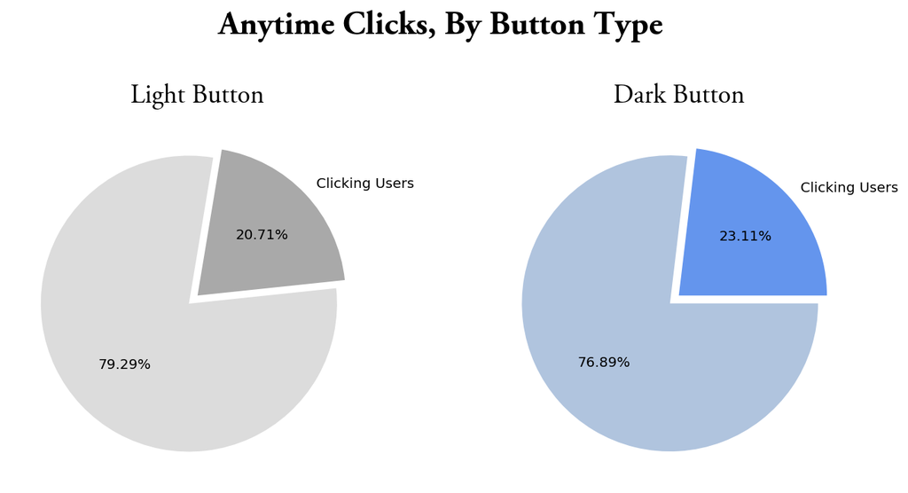

```python
labels = ['Clicking Users', '']
light_button_clicks = [click_button_ab_test['count'][0], click_button_ab_test['users'][0]-\
                      click_button_ab_test['count'][0]]
dark_button_clicks = [click_button_ab_test['count'][1], click_button_ab_test['users'][1]-\
                     click_button_ab_test['count'][1]]
adg_font = {'fontname':'Adobe Garamond Pro'}

fig, axs = plt.subplots(1, 2,figsize=(11, 6))
colors_lb = ['darkgray','gainsboro']
colors_db = ['cornflowerblue','lightsteelblue']

axs[0].pie(light_button_clicks, labels=labels, autopct='%1.2f%%', shadow=False, colors=colors_lb, explode = (0, 0.08)\
          , startangle = 6)
axs[0].set_title('Light Button', fontsize = 19, **adg_font)

axs[1].pie(dark_button_clicks, labels=labels, autopct='%1.2f%%', shadow=False, colors=colors_db, explode = (0, 0.08))
axs[1].set_title('Dark Button', fontsize = 19, **adg_font)

plt.subplots_adjust(wspace=0.3, hspace=1)
plt.suptitle("    Anytime Clicks, By Button Type", fontsize = 24, fontweight = 'bold', **adg_font)
plt.savefig("ex_A_clicks.png",dpi=300, bbox_inches='tight')
plt.show()
```

```python
send_button_ab_test
```

|  | count | users | proportion |
| --- | --- | --- | --- |
| light_button_sends | 1321 | 16593 | 0.08 |
| dark_button_sends | 712 | 16488 | 0.04 |

Back to Top

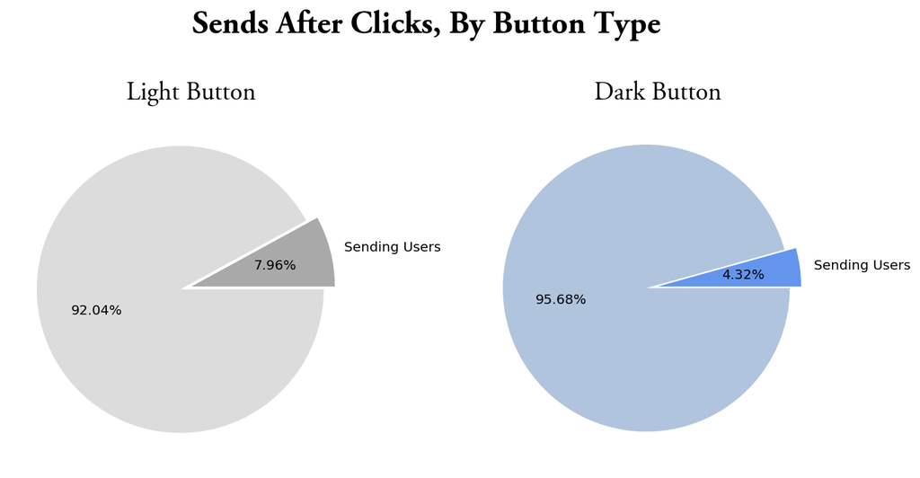

```python
labels = ['Sending Users', '']
light_button_sends = [send_button_ab_test['count'][0], send_button_ab_test['users'][0]-\
                     send_button_ab_test['count'][0]]
dark_button_sends = [send_button_ab_test['count'][1], send_button_ab_test['users'][1]-\
                    send_button_ab_test['count'][1]]
adg_font = {'fontname':'Adobe Garamond Pro'}

fig, axs = plt.subplots(1, 2,figsize=(11, 6))
colors_lb = ['darkgray','gainsboro']
colors_db = ['cornflowerblue','lightsteelblue']

axs[0].pie(light_button_sends, labels=labels, autopct='%1.2f%%', shadow=False, colors=colors_lb, explode = (0, 0.08))
axs[0].set_title('Light Button', fontsize = 19, **adg_font)

axs[1].pie(dark_button_sends, labels=labels, autopct='%1.2f%%', shadow=False, colors=colors_db, explode = (0, 0.08))
axs[1].set_title('Dark Button', fontsize = 19, **adg_font)

plt.subplots_adjust(wspace=0.3, hspace=1)
plt.suptitle("    Sends After Clicks, By Button Type", fontsize = 24, fontweight = 'bold', **adg_font)
plt.savefig("ex_B_send_it.png",dpi=300, bbox_inches='tight')
plt.show()
```

```python
click_to_send_conversions_funnel
```

|  | users | first-clicking users | sending users | conversion |
| --- | --- | --- | --- | --- |
| light_button | 16593 | 2957 | 1321 | 0.45 |
| dark_button | 16488 | 3194 | 712 | 0.22 |

Back to Top

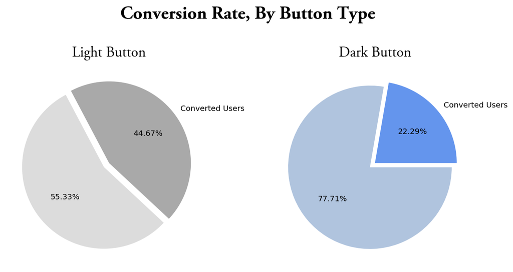

```python
labels = ['Converted Users', '']
light_button_converted_sends = \
  [click_to_send_conversions_funnel['sending users'][0], click_to_send_conversions_funnel['first-clicking users'][0]-\
  click_to_send_conversions_funnel['sending users'][0]]
dark_button_converted_sends = \
  [click_to_send_conversions_funnel['sending users'][1], click_to_send_conversions_funnel['first-clicking users'][1]-\
  click_to_send_conversions_funnel['sending users'][1]]
adg_font = {'fontname':'Adobe Garamond Pro'}

fig, axs = plt.subplots(1, 2,figsize=(11, 6))
colors_lb = ['darkgray','gainsboro']
colors_db = ['cornflowerblue','lightsteelblue']

axs[0].pie(light_button_converted_sends, labels=labels, autopct='%1.2f%%', shadow=False, \
           colors=colors_lb, explode = (0, 0.08), startangle = -43)
axs[0].set_title('Light Button', fontsize = 19, **adg_font)

axs[1].pie(dark_button_converted_sends, labels=labels, autopct='%1.2f%%', shadow=False, \
           colors=colors_db, explode = (0, 0.08))
axs[1].set_title('Dark Button', fontsize = 19, **adg_font)

plt.subplots_adjust(wspace=0.3, hspace=1)
plt.suptitle("      Conversion Rate, By Button Type", fontsize = 24, fontweight = 'bold', **adg_font)
plt.savefig("ex_C_converted_sends.png",dpi=300, bbox_inches='tight')
plt.show()
```

Back to Top